# Campy HGT

Julian Trachsel

9/22/2020

## Overview

Terms:

- Parental: The genomes which took part in the mating experiments
- Donor: The genome which was the source of the transferred AMR phenotype
- Recipient: The genome which the AMR phenotype was transferred into
- Result: The genome resulting from the mating of Donor and Recipient genomes

I am using a pangenome approach to identify genes that were transferred from the donor-genome to the recipient-genome making the result-genome. This means a pan genome is calculated for each mating experiment, and each of the calculated pangenomes contains exactly three genomes. Roary is used for calculating these pangenomes. For this analysis I increased the stringency for assigning coding sequences to a gene, all sequences assigned to a gene must be 99% identical (up from the standard 95%).

Transferred genes are those that are present in the donor and result genomes but not the recipient genome.

Another (potentially related) event is the deletion of genes. Genes that are present in the recipient genome but not the result genome are identified as deleted.

Sometimes transferred genes are grouped into consecutive strings of genes. These consecutive strings of transferred genes are referred to as ‘genomic islands’. Below a table of transferred genomic islands will be presented for each mating experiment, but keep in mind for the purposes of this report I have allowed genomic islands that consist of only 1 gene.

First we verify donor/recipient relationships between parental and result genomes.  
This is accomplished by calculating the alignment based average nucleotide identity for all pairwise combinations of genomes. In each mating experiment the parental genome with the greatest average nucleotide identity to the result genome is assigned as the recipient, the other genome is assigned as the donor.

### MDS plot

Visualizing pairwise ANI.

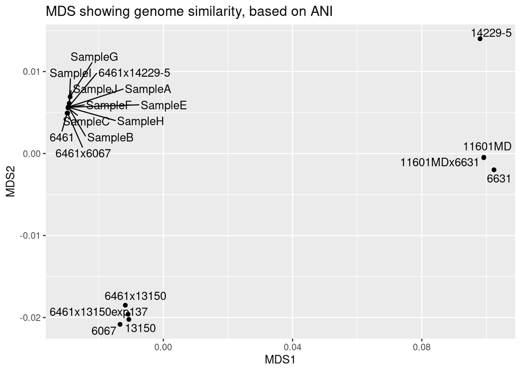

### Mating experiment table

This table lays out the mating experiments as they have been analysed below.

| donor_genome | recipient_genome | result_genome |
| --- | --- | --- |
| 6631 | 11601MD | 11601MDx6631 |
| 6461 | 13150 | 6461x13150 |
| 6461 | 13150 | 6461x13150exp137 |
| 14229-5 | 6461 | 6461x14229-5 |
| 6067 | 6461 | 6461x6067 |
| 14229-5 | 6461 | SampleA |
| 14229-5 | 6461 | SampleB |
| 14229-5 | 6461 | SampleC |
| 14229-5 | 6461 | SampleE |
| 14229-5 | 6461 | SampleF |
| 14229-5 | 6461 | SampleG |
| 14229-5 | 6461 | SampleH |
| 14229-5 | 6461 | SampleI |
| 14229-5 | 6461 | SampleJ |

## Results

Reporting results separately for each mating experiment.

For each experiment there will be the following items:  
1) Table of ‘genomic islands’  
2) Table of transferred genes  
3) Table of deleted genes  
4) plot showing where genomic islands are found in the donor and result genomes.

The tables in this report only contain a subset of the columns for viewing ease. Full versions of these tables are available in the results directory I will provide you.

Transferred genomic islands

| island_ID | quat_cluster | num_genes | island_type | RESISTANCE | res_type | HGT_role |
| --- | --- | --- | --- | --- | --- | --- |
| 14229-5_17_1 | 138 | 6 | AMR | AMIKACIN;GENTAMICIN;KANAMYCIN;TOBRAMYCIN | aph(2’’)-If<100%> | donor |
| 14229-5_18_1 | 137 | 1 | virulence | NA | NA | donor |
| 6461x14229-5_28_1 | 137 | 1 | virulence | NA | NA | result |
| 6461x14229-5_29_1 | 138 | 6 | AMR | AMIKACIN;GENTAMICIN;KANAMYCIN;TOBRAMYCIN | aph(2’’)-If<100%> | result |

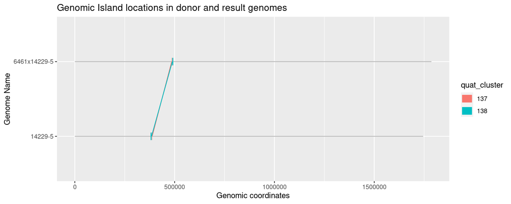

Transferred Genes

| Gene | all_Qclusters | Annotation | 14229-5 | 6461 | 6461x14229-5 |
| --- | --- | --- | --- | --- | --- |
| group_363 | 138 | IS200/IS605 family transposase IS605 | DIHJAPKI_00373 | NA | LMDBFIGE_00476 |
| group_364 | 138 | IS1595 family transposase ISCco2 | DIHJAPKI_00374 | NA | LMDBFIGE_00475 |
| group_365 | 138 | hypothetical protein | DIHJAPKI_00375 | NA | LMDBFIGE_00474 |
| group_366 | 138 | hypothetical protein | DIHJAPKI_00376 | NA | LMDBFIGE_00473 |
| group_367 | 138 | IS1595 family transposase ISAcsp6 | DIHJAPKI_00377 | NA | LMDBFIGE_00472 |
| group_368 | 138 | hypothetical protein | DIHJAPKI_00378 | NA | LMDBFIGE_00471 |
| group_369 | 137 | hypothetical protein | DIHJAPKI_00380 | NA | LMDBFIGE_00469 |

Deleted Genes

| Gene | all_Qclusters | Annotation | 14229-5 | 6461 | 6461x14229-5 |
| --- | --- | --- | --- | --- | --- |
| group_11 | 141 | hypothetical protein | NA | EKEIMHEI_00485 | NA |
| group_2094 | 106 | hypothetical protein | NA | EKEIMHEI_00468 | NA |
| group_7 | 126 | hypothetical protein | NA | EKEIMHEI_00302 | NA |